# SHAP Values and Random Forest

- Motivation:

The purpose of this assignment is to use to use the SHAP Values on a calssifier supervised learning model in order to explain the models' results and compare them.

- Resources:

  ```
    *Dataset on Loan Deafaults.
    *H2O Algorithms
    *Random Forest
  ```

- Methods:

  ```
    *GLM and Random Forest
    *Creating Dummy Variables for the Random Forest Algorithm
    *Multicollinearity and Variable Importance for Variable Selection
    *SHAP Values
  ```

- Objective:

Using the modified dataset of XYZ Loans with all the features created in the past assigment, modify the dataset so that it is suitable for a random forest model form the sklearn library and then calculate SHAP values to explain how the different variables affect the model performance.

```python
import pandas as pd
import os
import numpy as np
import seaborn as sns
import matplotlib.pyplot as plt
from math import ceil
from sklearn.model_selection import train_test_split
import h2o
from h2o.estimators.glm import H2OGeneralizedLinearEstimator
from statsmodels.stats.outliers_influence import variance_inflation_factor
from sklearn.ensemble import RandomForestClassifier
import shap
import re

os.chdir('/Users/luislosada/Columbia Drive/Anomaly Detection/Module 11')
```

```python
from h2o.estimators.random_forest import H2ORandomForestEstimator
h2o.init(nthreads=-1,enable_assertions = False)
```

```
Checking whether there is an H2O instance running at http://localhost:54321 . connected.
```

[output not shown]

```python
data = pd.read_csv("XYZloans_modified.csv",index_col = 0)
```

```python
data.head()
```

|  | id | loan_default | AP001 | AP002 | AP003 | AP005 | AP006 | AP007 | AP008 | AP009 | ... | CD166_bin | CD167_bin | CD169_bin | CD170_bin | CD172_bin | CD173_bin | MB005_bin | TD022_bin | TD023_bin | TD024_bin |
| --- | --- | --- | --- | --- | --- | --- | --- | --- | --- | --- | --- | --- | --- | --- | --- | --- | --- | --- | --- | --- | --- |
| 0 | 1 | 1 | 31 | 2 | 1 | 2017-07-06 10:21:00 | ios | 3 | 3 | 1 | ... | (-98.0, 5311.222] | (-98.0, 3208.889] | (-98.0, 9731.111] | (-98.0, 5985.222] | (-98.0, 13840.889] | (-98.0, 9614.222] | (4.947, 7.421] | (9.31, 10.345] | (8.276, 9.31] | (5.172, 6.207] |
| 1 | 2 | 0 | 27 | 1 | 1 | 2017-04-06 12:51:00 | h5 | 5 | 4 | 0 | ... | NoValue | NoValue | NoValue | NoValue | NoValue | NoValue | NoValue | (14.483, 15.517] | (5.172, 6.207] | NoValue |
| 2 | 3 | 0 | 33 | 1 | 4 | 2017-07-01 14:11:00 | h5 | 4 | 2 | 0 | ... | (-98.0, 5311.222] | (-98.0, 3208.889] | (-98.0, 9731.111] | (-98.0, 5985.222] | (-98.0, 13840.889] | (-98.0, 9614.222] | (7.421, 9.895] | (14.483, 15.517] | (8.276, 9.31] | (1.034, 2.069] |
| 3 | 4 | 0 | 34 | 2 | 4 | 2017-07-07 10:10:00 | android | 5 | 5 | 0 | ... | (-98.0, 5311.222] | (-98.0, 3208.889] | (-98.0, 9731.111] | (-98.0, 5985.222] | (-98.0, 13840.889] | (-98.0, 9614.222] | (9.895, 12.368] | NoValue | NoValue | NoValue |
| 4 | 5 | 0 | 47 | 2 | 1 | 2017-07-06 14:37:00 | h5 | 4 | 4 | 1 | ... | NoValue | NoValue | NoValue | NoValue | NoValue | NoValue | NoValue | (9.31, 10.345] | (2.069, 3.103] | NoValue |

5 rows × 80 columns

##### Modeling for Variable Selection

The dataset has already gone through a thorough process of feature engineering but The dataset right now has 78 predictors and one target variable. This might be too many variables,lets try to limit the ammount of variables for our model so that the algorithm can perform faster and more efficiently.

Lets start by defining the features and target variables and the train and test sets and then running a GLM model.

```python
features = list(data.columns)
target = "loan_default"
features.remove("loan_default")
features.remove("id")
```

```python
train, test = train_test_split(
     data, test_size=0.30, random_state=42)

train = train.reset_index()

train_smpl = train.sample(frac=0.1, random_state=1)
test_smpl = test.sample(frac=0.1, random_state=1)
train_hex = h2o.H2OFrame(train_smpl)
test_hex = h2o.H2OFrame(test_smpl)
```

```
Parse progress: |█████████████████████████████████████████████████████████| 100%
Parse progress: |█████████████████████████████████████████████████████████| 100%
```

```python
#Removing Variables with multicollinearity
glm_v1 = H2OGeneralizedLinearEstimator(family= "binomial", lambda_ = 0,remove_collinear_columns = True,model_id = 'glm_v1') #, compute_p_values = True)
glm_v1.train(features,target,training_frame=train_hex,validation_frame = test_hex)
```

```
glm Model Build progress: |███████████████████████████████████████████████| 100%
```

The GLM algorithm in H2O has an option to remove variables that have a high multicollinearity. By selecting the predictors used we can see which variables the model rejected. Lets store these variables then.

```python
#Removing collinear variables
lok = list(glm_v1.coef().keys())
predictors = list(set([lok[i].split('.', 1)[0] for i in range(len(lok))]))
predictors.remove('Intercept')
predictors
```

['CD167_bin', 'CD072_bin', 'PA031_bin', 'CD173_bin', 'CR004', 'PA028_bin', 'CD114_bin', 'CD164_bin', 'CR005', 'CR018', 'CD118_bin', 'CD101_bin', 'CD115_bin', 'AP009', 'CD160_bin', 'CR015', 'TD014', 'CD071_bin', 'AP001', 'AP007', 'TD001', 'TD013', 'CD130_bin', 'CD169_bin', 'CD107_bin', 'CD153_bin', 'CD121_bin', 'PA029_bin', 'CD135_bin', 'TD024_bin', 'AP003', 'TD006', 'MB005_bin', 'AP008', 'CD131_bin', 'TD023_bin', 'TD005', 'CD137_bin', 'MB007', 'TD022_bin', 'PA023_bin', 'CD008_bin', 'CD108_bin', 'PA022_bin', 'CD113_bin', 'AP006', 'CD106_bin', 'PA030_bin', 'CD136_bin', 'AP002', 'CD088_bin', 'AP005', 'CD132_bin', 'TD009', 'TD010', 'TD015', 'CD166_bin', 'TD051', 'TD054', 'CD170_bin', 'CD120_bin', 'TD002', 'CD133_bin', 'CR017', 'CD018_bin', 'CD100_bin', 'CD123_bin', 'CR019', 'CR009', 'CD172_bin', 'CD152_bin', 'CD117_bin', 'CD162_bin']

##### Variable Importance

Another useful technique for variable selection is the variable importance metric in a tree based algorithm like random forest. The concept behind the Variable Importance measurement is that a variable importance is measured on how many times the variable is selected to split the nodes of the tree.

```python
#random forest with H20
rf_v1 = H2ORandomForestEstimator(
        model_id = 'rf_v1',
        distribution="bernoulli",
        nfolds=10,
        fold_assignment="Modulo",
        keep_cross_validation_predictions=True,
        seed=1234,
        stopping_metric = "AUC")
rf_v1.train(predictors,target,training_frame=train_hex,validation_frame = test_hex)
```

```
drf Model Build progress: |███████████████████████████████████████████████| 100%
```

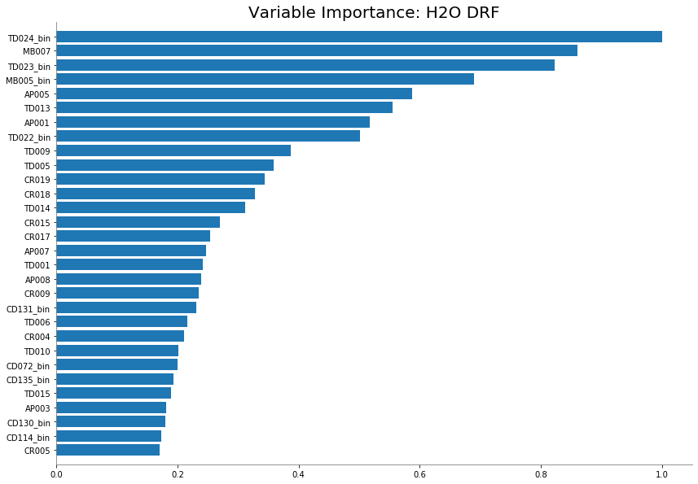

```python
rf_v1.varimp_plot(30)
```

By creating a threshold I can reject variables that have little to no effect on the model.

```python
#Select Variables
var_imp_df = pd.DataFrame(rf_v1.varimp(),columns = ['variable','relative_importance','scaled_importance','percentage'])
var_imp_df.tail(20)
```

|  | variable | relative_importance | scaled_importance | percentage |
| --- | --- | --- | --- | --- |
| 53 | CD132_bin | 85.793762 | 0.044763 | 0.003229 |
| 54 | CD170_bin | 84.260963 | 0.043963 | 0.003171 |
| 55 | CD137_bin | 74.068855 | 0.038645 | 0.002787 |
| 56 | CD167_bin | 65.303299 | 0.034072 | 0.002457 |
| 57 | CD101_bin | 62.565514 | 0.032643 | 0.002354 |
| 58 | CD173_bin | 54.707508 | 0.028543 | 0.002059 |
| 59 | CD166_bin | 32.652908 | 0.017037 | 0.001229 |
| 60 | CD164_bin | 32.445927 | 0.016929 | 0.001221 |
| 61 | CD169_bin | 24.772470 | 0.012925 | 0.000932 |
| 62 | CD172_bin | 22.766468 | 0.011878 | 0.000857 |
| 63 | CD108_bin | 20.518497 | 0.010705 | 0.000772 |
| 64 | CD008_bin | 19.587971 | 0.010220 | 0.000737 |
| 65 | CD107_bin | 15.113626 | 0.007885 | 0.000569 |
| 66 | CD100_bin | 13.158134 | 0.006865 | 0.000495 |
| 67 | CD106_bin | 7.795756 | 0.004067 | 0.000293 |
| 68 | CD153_bin | 1.405838 | 0.000733 | 0.000053 |
| 69 | CD152_bin | 1.381667 | 0.000721 | 0.000052 |
| 70 | CD162_bin | 1.267857 | 0.000662 | 0.000048 |
| 71 | TD051 | 0.000000 | 0.000000 | 0.000000 |
| 72 | TD054 | 0.000000 | 0.000000 | 0.000000 |

The random forest algorithm has three important metrics that complement each other. The original measurement is called the relative importance and measures the importance of the variable in all the trees created. The scaled importance then scales this importance in comparison to the rest of the variables.

To select my variables then I will create a threshold were anything that has a scaled importance of below 10% will be rejected.

```python
#Threshold of 10% scaled importance to reduce variable selection
new_features_df = var_imp_df[var_imp_df.scaled_importance > 0.10]
new_features = list(new_features_df.variable)
new_features_df.relative_importance.describe()
```

```
count      47.000000
mean      532.470851
std       410.837801
min       195.371780
25%       260.866821
50%       384.130127
75%       611.879120
max      1916.637939
Name: relative_importance, dtype: float64
```

###### Cleaning the variables

Some variables have too many categories which makes it harder for the algorithm to grasp the contents of the variable and might make it work harder whihc in tunr gives it a false sense importance as the algorithm selects that variable just because splitting into so many catergories produces many different results.

In this particular dataset the variables MB007 (system) and AP005 (dates) have more than 5 categories. Lets fix that.

```python
pd.set_option('display.max_rows', 200)
pd.DataFrame(data["MB007"].value_counts()).index.tolist()
```

['WEB', 'IPHONE7', 'IPHONE8', 'OPPO', 'IPHONE9', 'VIVO', 'HUAWEI', 'Noinfo', 'SAMSUNG', 'XIAOMI', 'HONOR', 'IPHONE6', 'MEIZU', 'GIONEE', 'LEECO', 'IPHONE5', 'LETV', '360', 'COOLPAD', 'IPHONE4', 'ZTE', 'NUBIA', 'MEITU', 'LENOVO', 'ONEPLUS', 'SMARTISAN', 'HTC', 'SONY', 'IPAD4', 'QIKU', 'CMCC', 'HISENSE', 'DOOV', 'MOTOROLA', 'CMDC', 'IVVI', 'XIAOLAJIAO', 'ZUK', 'KOOBEE', 'IPAD5', 'ALPS', 'NOKIA', 'ASUS', 'SUGAR', 'YUFLY', 'CHANGHONG', '4G', 'IPOD7', 'KOPO', 'IPHONE3', 'GOOGLE', 'KONKA', 'YEPEN', 'OWWO', 'IPAD6', 'SGMSGMS', 'LGE', 'BIRD', 'YU-FLY', 'IPAD3', 'BIFER', 'UOOGOU', 'IPAD2', 'PHILIPS', 'ROAM_CAT', 'CHINAMOBILE', 'ANDROID', 'SKYHON', 'REDGOO', 'HMI', 'DAQ', 'CONGMETAL', 'FOPAD', 'BOOWUN', 'LEPHONE', 'VOLTE', 'SM-W2016', 'RAMOS', 'KINGSUN', 'MEDIATEK', 'MANN', 'MC-X7MINI', 'X6', 'YTONE_L985', 'HONGLAJIAO', 'MONEYMAKINGMACHINE', 'VOTO', 'PROTRULY', 'HRT', 'DOOVL5PRO', 'MYTEL', 'BOWAY', 'TCT', 'TCL', 'APPLE', 'VETAS', 'HASEE', 'EYU', 'GO', 'BEN13', 'KDDI', 'F8926', 'OUKI', 'VEGA', 'MILAI', 'TINAI', 'VERIZON', 'AMOI', 'LINGWIN', 'MLLED', 'ZUOKU', 'AND']

```python
for k in range(len(data["MB007"])):
    var = re.split(r'(\d+)', data.loc[k,"MB007"])[0]
    if var == "WEB":
        data.loc[k,"MB007"] = 'PC'
    elif var == "IPHONE" or var == "IPAD" or var == "IPOD" or var == "APPLE" :
        data.loc[k,"MB007"] = 'APPLE'
    elif var == "SAMSUNG":
        data.loc[k,"MB007"] = 'SAMSUNG'
    elif var =="HUAWEI" or var =="OPPO" or var =="XIAOMI" or var =="MEIZU" or var =="HONOR" or var =="GIONEE" or var =="LEECO" or var =="ZTE" or var =="NUBIA" or var =="ASUS":
        data.loc[k,"MB007"] = 'ANDROID_ASIA'
    elif var == "Noinfo":
        data.loc[k,"MB007"] = 'Noinfo'
    elif var =="SONY" or var =="MOTOROLA" or var =="ONEPLUS" or var =="LENOVO" or var =="HTC" or var =="NOKIA" or var =="GOOGLE":
        data.loc[k,"MB007"] = 'ANDROID_BIG_BRAND'
    else:
        data.loc[k,"MB007"] = 'OTHER'
```

By combining values into a broader category I can reduce the categories and still not lose the predictive power of the variable.

```python
pd.DataFrame(data["MB007"].value_counts())
```

|  | MB007 |
| --- | --- |
| PC | 43850 |
| APPLE | 17120 |
| ANDROID_ASIA | 10791 |
| OTHER | 4381 |
| Noinfo | 2055 |
| SAMSUNG | 1646 |
| ANDROID_BIG_BRAND | 157 |

AP005 is worst. Each date is put into a category which means there are about 55k categories. A way to fix this is by using a Year-Month combination of the dates. This reduces the categories to only 5.

```python
data['AP005'] = pd.to_datetime(data['AP005'])
pd.DataFrame(data["AP005"].value_counts())
```

|  | AP005 |
| --- | --- |
| 2017-06-19 16:35:00 | 8 |
| 2017-05-08 15:38:00 | 7 |
| 2017-07-07 14:58:00 | 7 |
| 2017-06-29 15:24:00 | 7 |
| 2017-04-27 13:30:00 | 7 |
| ... | ... |
| 2017-05-05 07:16:00 | 1 |
| 2017-06-04 15:23:00 | 1 |
| 2017-04-01 16:57:00 | 1 |
| 2017-04-07 11:52:00 | 1 |
| 2017-06-28 14:39:00 | 1 |

55057 rows × 1 columns

```python
data['AP005'] = data['AP005'].map(lambda x: 100*x.year + x.month)
data['AP005'] = ['d_'+str(data.loc[i,'AP005']) for i in range(len(data['AP005']))]
```

```python
data['AP005'] = data['AP005'].astype('object',copy=False)
data['AP005'].value_counts()
```

```
d_201706    24386
d_201705    23779
d_201704    18352
d_201707    13078
d_201703      405
Name: AP005, dtype: int64
```

###### Random Forest on sklearn

The random forest algorithm in the sklearn library requires some feature engineering for it to perform at its best. Categorical variables are not interpreted as categories by the algorithm and therefore have no predictive power on the model. To solve this problem, I will create dummy variables of each category of each categorical variable. That way the model will be able to interpret the categories.

```python
#Hot encoding of categorical variables
cat_var = pd.DataFrame(pd.DataFrame(data[new_features].dtypes).iloc[:,0][pd.DataFrame(data[new_features].dtypes).iloc[:,0] == 'object']).index.tolist()
for i in range(len(cat_var)):
    if i != 0:
        temp_df = pd.get_dummies(data[cat_var[i]])
        temp_df.columns = [cat_var[i]+"_"+temp_df.columns.tolist()[j] for j in range(len(temp_df.columns.tolist()))]
        prev_df = pd.concat([prev_df, temp_df], axis=1)
    else:
        prev_df = pd.get_dummies(data[cat_var[i]])
        prev_df.columns = [cat_var[i]+"_"+prev_df.columns.tolist()[j] for j in range(len(prev_df.columns.tolist()))]
prev_df
```

|  | TD024_bin_(1.034, 2.069] | TD024_bin_(11.379, 12.414] | TD024_bin_(13.448, 14.483] | TD024_bin_(15.517, 16.552] | TD024_bin_(17.586, 18.621] | TD024_bin_(19.655, 20.69] | TD024_bin_(21.724, 22.759] | TD024_bin_(23.793, 24.828] | TD024_bin_(25.862, 26.897] | TD024_bin_(27.931, 28.966] | ... | PA029_bin_(-98.0, 232.0] | PA029_bin_(-99.0, -98.0] | PA029_bin_(1222.0, 1552.0] | PA029_bin_(1552.0, 1882.0] | PA029_bin_(1882.0, 2212.0] | PA029_bin_(232.0, 562.0] | PA029_bin_(2542.0, 2872.0] | PA029_bin_(562.0, 892.0] | PA029_bin_(892.0, 1222.0] | PA029_bin_NoValue |
| --- | --- | --- | --- | --- | --- | --- | --- | --- | --- | --- | --- | --- | --- | --- | --- | --- | --- | --- | --- | --- | --- |
| 0 | 0 | 0 | 0 | 0 | 0 | 0 | 0 | 0 | 0 | 0 | ... | 0 | 1 | 0 | 0 | 0 | 0 | 0 | 0 | 0 | 0 |
| 1 | 0 | 0 | 0 | 0 | 0 | 0 | 0 | 0 | 0 | 0 | ... | 0 | 1 | 0 | 0 | 0 | 0 | 0 | 0 | 0 | 0 |
| 2 | 1 | 0 | 0 | 0 | 0 | 0 | 0 | 0 | 0 | 0 | ... | 0 | 1 | 0 | 0 | 0 | 0 | 0 | 0 | 0 | 0 |
| 3 | 0 | 0 | 0 | 0 | 0 | 0 | 0 | 0 | 0 | 0 | ... | 0 | 1 | 0 | 0 | 0 | 0 | 0 | 0 | 0 | 0 |
| 4 | 0 | 0 | 0 | 0 | 0 | 0 | 0 | 0 | 0 | 0 | ... | 0 | 0 | 0 | 0 | 0 | 0 | 0 | 0 | 0 | 1 |
| ... | ... | ... | ... | ... | ... | ... | ... | ... | ... | ... | ... | ... | ... | ... | ... | ... | ... | ... | ... | ... | ... |
| 79995 | 0 | 0 | 0 | 0 | 0 | 0 | 0 | 0 | 0 | 0 | ... | 0 | 1 | 0 | 0 | 0 | 0 | 0 | 0 | 0 | 0 |
| 79996 | 0 | 0 | 0 | 0 | 0 | 0 | 0 | 0 | 0 | 0 | ... | 0 | 1 | 0 | 0 | 0 | 0 | 0 | 0 | 0 | 0 |
| 79997 | 0 | 0 | 0 | 0 | 0 | 0 | 0 | 0 | 0 | 0 | ... | 0 | 1 | 0 | 0 | 0 | 0 | 0 | 0 | 0 | 0 |
| 79998 | 0 | 0 | 0 | 0 | 0 | 0 | 0 | 0 | 0 | 0 | ... | 0 | 1 | 0 | 0 | 0 | 0 | 0 | 0 | 0 | 0 |
| 79999 | 0 | 0 | 0 | 0 | 0 | 0 | 0 | 0 | 0 | 0 | ... | 1 | 0 | 0 | 0 | 0 | 0 | 0 | 0 | 0 | 0 |

80000 rows × 225 columns

```python
#skicit learn random forest
df_rf = data[['loan_default'] + new_features].drop(columns = cat_var)
df_rf = pd.concat([df_rf,prev_df], axis=1)
```

```python
df_rf = df_rf.apply(pd.to_numeric)
pd.DataFrame(df_rf.dtypes)[pd.DataFrame(df_rf.dtypes).iloc[:,0] != 'int64']
```

|  | 0 |
| --- | --- |
| TD024_bin_(1.034, 2.069] | uint8 |
| TD024_bin_(11.379, 12.414] | uint8 |
| TD024_bin_(13.448, 14.483] | uint8 |
| TD024_bin_(15.517, 16.552] | uint8 |
| TD024_bin_(17.586, 18.621] | uint8 |
| ... | ... |
| PA029_bin_(232.0, 562.0] | uint8 |
| PA029_bin_(2542.0, 2872.0] | uint8 |
| PA029_bin_(562.0, 892.0] | uint8 |
| PA029_bin_(892.0, 1222.0] | uint8 |
| PA029_bin_NoValue | uint8 |

225 rows × 1 columns

- Splitting the data:

For this exercise I will be calculating SHAP values (more on this later on). This calculations can sometimes take a lot of time so, to reduce time, I will calculate these values on a smaller sample of my dataset.

```python
y = df_rf['loan_default']
X = df_rf.drop(columns = ['loan_default'])
X_train, X_test, y_train, y_test = train_test_split(
    X, y, test_size=0.8, random_state=1)
X_train, X_val, y_train, y_val = train_test_split(
    X_train, y_train, test_size=0.8, random_state=1)
```

```python
X_train.shape
```

```
(3200, 247)
```

```python
clf=RandomForestClassifier(n_estimators=100)

#Train the model using the training sets y_pred=clf.predict(X_test)
clf.fit(X_train,y_train)
```

```
RandomForestClassifier(bootstrap=True, class_weight=None, criterion='gini',
            max_depth=None, max_features='auto', max_leaf_nodes=None,
            min_impurity_decrease=0.0, min_impurity_split=None,
            min_samples_leaf=1, min_samples_split=2,
            min_weight_fraction_leaf=0.0, n_estimators=100, n_jobs=None,
            oob_score=False, random_state=None, verbose=0,
            warm_start=False)
```

##### SHAP Values

SHAP Values come from the Shapley value which can be defined as "the measurement of the average marginal contribution across all permutations of a model". The SHAP Value is then the measurment of the effect of each variable against the other and the model and its correlation be it negative or positive. Lets satrt by using the mean SHAP value to calculate the variable importance per class for each variable.

```python
#shap values
shap_values = shap.TreeExplainer(clf).shap_values(X_train)
```

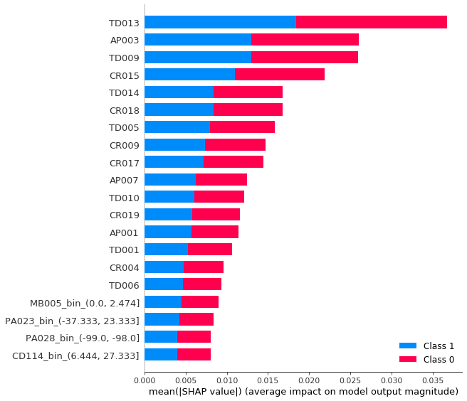

```python
shap.summary_plot(shap_values, X_train, plot_type="bar")
```

- TD013 seem so be the most important variable.
- On our H2O Random forest algorithm the most important variables were Binned variables but for this algorithm binned variables were turned into dummy variables which makes it loose some of its predictive power as a whole.
- The classes for each of the most important variables seem to be very well represented in the importance of the model.

```python
# Get the predictions and put them with the test data.
X_output = X_test.copy()
X_output.loc[:,'predict'] = np.round(clf.predict(X_output),2)

# Randomly pick some observations
random_picks = np.arange(1,330,50) # Every 50 rows
S = X_output.iloc[random_picks]
S
```

|  | TD013 | AP001 | TD009 | TD005 | CR019 | CR018 | TD014 | CR015 | CR017 | AP007 | ... | PA029_bin_(-99.0, -98.0] | PA029_bin_(1222.0, 1552.0] | PA029_bin_(1552.0, 1882.0] | PA029_bin_(1882.0, 2212.0] | PA029_bin_(232.0, 562.0] | PA029_bin_(2542.0, 2872.0] | PA029_bin_(562.0, 892.0] | PA029_bin_(892.0, 1222.0] | PA029_bin_NoValue | predict |
| --- | --- | --- | --- | --- | --- | --- | --- | --- | --- | --- | --- | --- | --- | --- | --- | --- | --- | --- | --- | --- | --- |
| 46624 | 10 | 25 | 10 | 6 | 9 | 7 | 4 | 5 | 7 | 5 | ... | 1 | 0 | 0 | 0 | 0 | 0 | 0 | 0 | 0 | 0 |
| 27922 | 1 | 32 | 1 | 1 | 2 | 2 | 2 | 4 | 2 | 1 | ... | 1 | 0 | 0 | 0 | 0 | 0 | 0 | 0 | 0 | 0 |
| 69508 | 1 | 47 | 2 | 2 | 11 | 3 | 1 | 6 | 8 | 4 | ... | 1 | 0 | 0 | 0 | 0 | 0 | 0 | 0 | 0 | 0 |
| 40831 | 0 | 35 | 0 | 0 | 2 | 1 | 0 | 5 | 1 | 5 | ... | 1 | 0 | 0 | 0 | 0 | 0 | 0 | 0 | 0 | 0 |
| 67079 | 2 | 36 | 2 | 2 | 3 | 3 | 2 | 6 | 3 | 5 | ... | 1 | 0 | 0 | 0 | 0 | 0 | 0 | 0 | 0 | 0 |
| 73134 | 9 | 28 | 5 | 2 | 11 | 8 | 7 | 5 | 8 | 4 | ... | 1 | 0 | 0 | 0 | 0 | 0 | 0 | 0 | 0 | 0 |
| 18468 | 3 | 50 | 3 | 3 | 5 | 3 | 0 | 3 | 4 | 5 | ... | 1 | 0 | 0 | 0 | 0 | 0 | 0 | 0 | 0 | 0 |

7 rows × 248 columns

- Simplified Importance Variable

This graph shows a bit of a different representation of the variable importance plot. Here each variable's importance is plotted and the correlation of that variable to the target variable is expressed by the color of the bar where Red is a positive impact and blue is a negative impact.

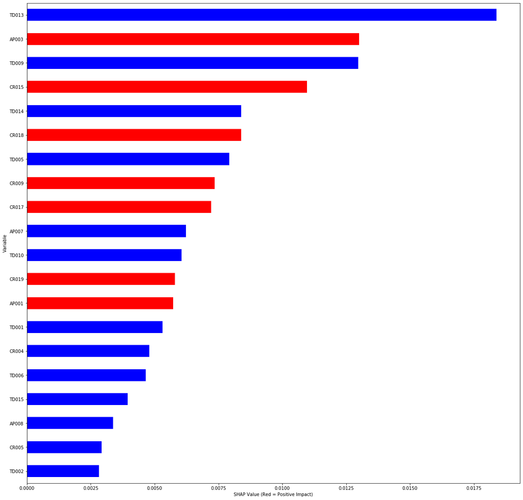

```python
def ABS_SHAP(df_shap,df):
    #import matplotlib as plt
    # Make a copy of the input data
    shap_v = pd.DataFrame(df_shap[0]).iloc[:,0:20]
    feature_list = df.iloc[:,0:20].columns
    shap_v.columns = feature_list
    df_v = df.copy().reset_index().drop('index',axis=1)

    # Determine the correlation in order to plot with different colors
    corr_list = list()
    for i in feature_list:
        b = np.corrcoef(shap_v[i],df_v[i])[1][0]
        corr_list.append(b)
    corr_df = pd.concat([pd.Series(feature_list),pd.Series(corr_list)],axis=1).fillna(0)
    # Make a data frame. Column 1 is the feature, and Column 2 is the correlation coefficient
    corr_df.columns  = ['Variable','Corr']
    corr_df['Sign'] = np.where(corr_df['Corr']>0,'red','blue')

    # Plot it
    shap_abs = np.abs(shap_v)
    k=pd.DataFrame(shap_abs.mean()).reset_index()
    k.columns = ['Variable','SHAP_abs']
    k2 = k.merge(corr_df,left_on = 'Variable',right_on='Variable',how='inner')
    k2 = k2.sort_values(by='SHAP_abs',ascending = True)
    colorlist = k2['Sign']
    ax = k2.plot.barh(x='Variable',y='SHAP_abs',color = colorlist, figsize=(20,20),legend=False)
    ax.set_xlabel("SHAP Value (Red = Positive Impact)")

ABS_SHAP(shap_values,X_train)
```

- Summary of the Shap Values

Now lets interpret the summary plot of all the SHAP values of the model. The top variables re showcased here and as we can see TD013 a high level of TD013 seems to porduce a negative impact on the model. Completely the opposite to AP003, as the values get higher the impact becomes more positive. Yet it seems that the variables that have more negative impact on the model are the most important ones in this case.

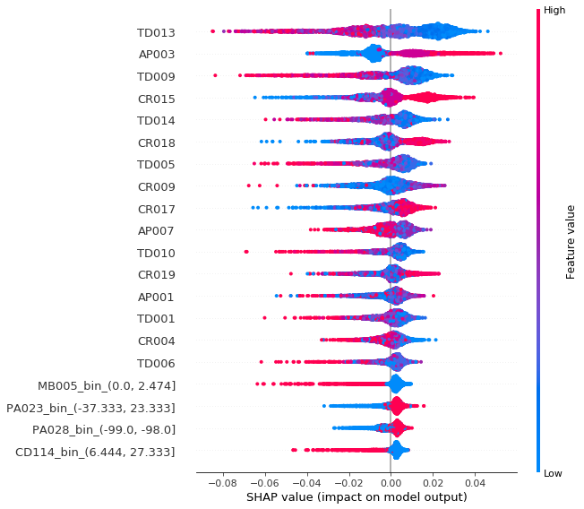

```python
shap.summary_plot(shap_values[0], X_train)
```

##### Dependence Plot

The dependence plot for TD013 shows that in fact there's a negative trend between TD013 and the target variable.

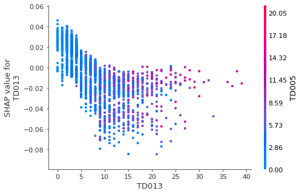

```python
shap.dependence_plot('TD013', shap_values[0], X_train)
```

- Different instances

AP003 shows a special case of a variable that is not continous. The values of AP003 concentrate around 4 specific points (1,3,4,5). However, the relationship is positive overall and the variable interacts with TD009 a lot.

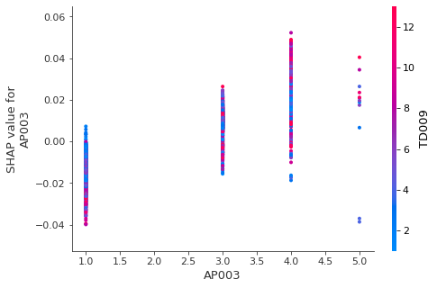

```python
shap.dependence_plot('AP003', shap_values[0], X_train)
```

#### SHAP Plot for Observation Importance

Each observation provides a different output on the model based on the formula created for that model. Lets test out then how different observations can affect the model and how the variables push the output of the model in each case. A random selection of observations will be used here to show the results.

```python
shap.initjs()

# Write in a function
def shap_plot(j):
    X_output = X_test.copy()
    X_output.loc[:,'predict'] = np.round(clf.predict(X_output),2)

    # Randomly pick some observations
    random_picks = np.arange(1,330,50) # Every 50 rows
    S = X_output.iloc[random_picks]
    explainerModel = shap.TreeExplainer(clf)
    shap_values_Model = explainerModel.shap_values(S)
    p = shap.force_plot(base_value=explainerModel.expected_value[0], shap_values=shap_values_Model[0][j,:], features=S.iloc[j,:])

    return(p)
shap_plot(0)
```

```python
shap_plot(1)
```

```python
shap_plot(2)
```

```python
shap_plot(3)
```